# Tidy data: restructuring

Day 9

## Two main ways to structure a dataset

1. `wide` data typically represent unique variables via columns (in extreme cases, may have more columns than rows)
2. `narrow\long` data represent values in columns but each row represents a different case (typically has more rows than columns)
- Today we will learn how to convert a dataset from one type to the other and vice versa

## Typical “spreadsheet” data: wide `babynames`

```
# A tibble: 5 x 10
  sex   name  `1880` `1881` `1882` `1883` `1884` `1885` `1886` `1887`
  <chr> <chr>  <int>  <int>  <int>  <int>  <int>  <int>  <int>  <int>
1 F     Anna    2604   2698   3143   3306   3860   3994   4283   4227
2 F     James     22     24     18     25     33     26     29     19
3 F     Mary    7065   6919   8148   8012   9217   9128   9889   9888
4 M     Anna      12     16     NA     16     20     20     15     13
5 M     James   5927   5441   5892   5223   5693   5175   5355   4768
```

- rows: unique name/sex combo
- columns: many, many columns containing the same type of value measured in a different year
- When is this format useful?

## tidy data: narrow `babynames`

```
# A tibble: 1,924,665 x 5
   year sex   name          n   prop
  <dbl> <chr> <chr>     <int>  <dbl>
1  1880 F     Mary       7065 0.0724
2  1880 F     Anna       2604 0.0267
3  1880 F     Emma       2003 0.0205
4  1880 F     Elizabeth  1939 0.0199
5  1880 F     Minnie     1746 0.0179
6  1880 F     Margaret   1578 0.0162
7  1880 F     Ida        1472 0.0151
8  1880 F     Alice      1414 0.0145
# ... with 1,924,657 more rows
```

- rows: each `case` refers to unique name/sex/year combo
- columns: `variables` containing the same type of value for each row
  - count/prop for each case
- when is this format useful?

## Tidy Data

- more long than wide
- Pros:
  - scalable, easier to add more variables and join other tables
    - How would `prop` be added to “wide” `babynames` format?
  - more efficient storage/retrieval
  - usually easier to analyze (graph, model, etc)
- Cons:
  - harder to “see” all data in spreadsheet
- Management of data
  - done via code, not within spreadsheet app
  - fits our philosophy of “reproducibility”

## Reshaping data: wide format

- Here are 2014 and 2015 grad rates for 3 schools (cases):

```
   school gradRate_2015 gradRate_2014   region
1  Aitkin          93.0          94.6 northern
2 Bemidji          86.2          83.2 northern
3  Chaska          96.2          92.7    metro
```

- We want to analyze graduation trends by year
- How would we plot this data?
  - `ggplot(data,aes(x=year,y=gradRate))`
- We can convert data between wide and narrow (long) formats to suit our analysis needs

## Reshaping data: from wide to narrow

- The `tidyr` package let’s us go between narrow and long formats
- `gather(wide, key=, value=, ..cols to gather..)`
  - `key` is the **(new)** variable name that will ID cases
  - `value` is the **(new)** variable name given to the gathered values
  - `cols to gather`: comma separated names of columns to gather
- any variables that are not gathered will have values repeated

## Reshaping data: wide to narrow

- Our values to fill are grad rates and our cases will be defined by school/year combinations so `year` is the `key` (`school` is already a variable):

```r
> grad_narrow <- gather(grad_wide, key = year, value=gradRate, gradRate_2015, gradRate_2014)
> grad_narrow
   school   region          year gradRate
1  Aitkin northern gradRate_2015     93.0
2 Bemidji northern gradRate_2015     86.2
3  Chaska    metro gradRate_2015     96.2
4  Aitkin northern gradRate_2014     94.6
5 Bemidji northern gradRate_2014     83.2
6  Chaska    metro gradRate_2014     92.7
```

- The year variable is not quite a number though…

## Reshaping data: `parse_number`

- We can use the `readr` package’s command `parse_number` to clean up `year` levels
  - drops non-numerics before/after first numeric value(s)

```r
> grad_narrow <- grad_narrow %>% mutate(year=parse_number(year))
> grad_narrow
   school   region year gradRate
1  Aitkin northern 2015     93.0
2 Bemidji northern 2015     86.2
3  Chaska    metro 2015     96.2
4  Aitkin northern 2014     94.6
5 Bemidji northern 2014     83.2
6  Chaska    metro 2014     92.7
```

## Plotting grad rates

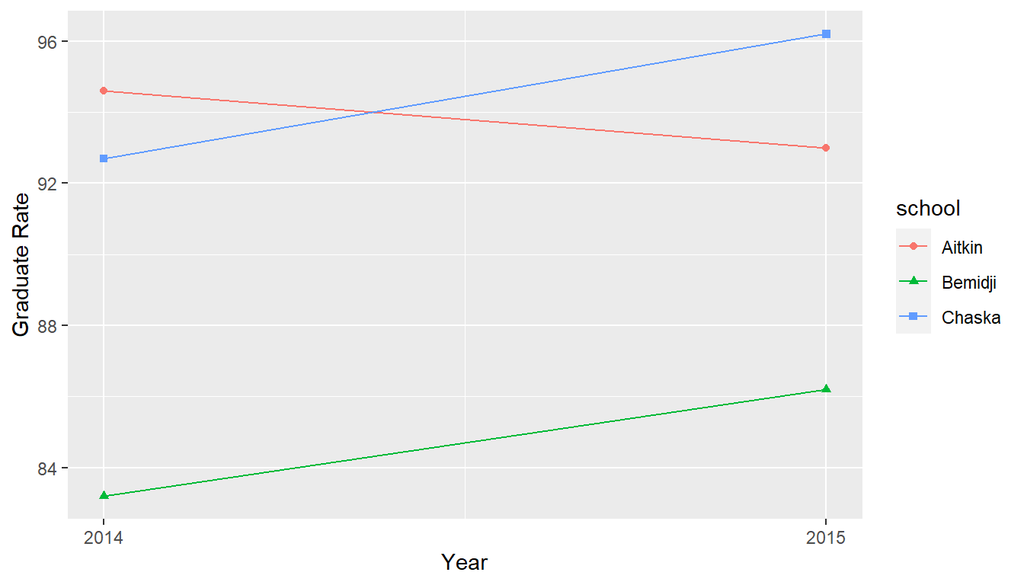

```r
> ggplot(grad_narrow, aes(x=year,y=gradRate)) + geom_line(aes(color=school))+
+   geom_point(aes(color=school,shape=school)) + labs(x="Year",y="Graduate Rate") +
+   scale_x_continuous(breaks=c(2014,2015))
```

## Reshaping data: wide format

- What about `wide` data with two time varying variables?
- Here are 2014 and 2015 4- and 6-year grad rates for 3 schools (cases):

```
# A tibble: 3 x 6
  school  gradRate4_2015 gradRate4_2014 region   gradRate6_2015 gradRate6_2014
  <chr>            <dbl>          <dbl> <chr>             <dbl>          <dbl>
1 Aitkin            93             94.6 northern           93.5           94.5
2 Bemidji           86.2           83.2 northern           90.3           88.4
3 Chaska            96.2           92.7 metro              98.4           97.8
```

## Reshaping data: wide to narrow

- Our values to fill are grad rates and our cases will be defined by school/year combinations so `year` is the `key`:

```r
> grad_narrower <- gather(grad_wider, key = year, value=gradRate, c(2,3,5,6))
> grad_narrower %>% as_tibble() %>% print(n=7)
# A tibble: 12 x 4
  school  region   year           gradRate
  <chr>   <chr>    <chr>             <dbl>
1 Aitkin  northern gradRate4_2015     93
2 Bemidji northern gradRate4_2015     86.2
3 Chaska  metro    gradRate4_2015     96.2
4 Aitkin  northern gradRate4_2014     94.6
5 Bemidji northern gradRate4_2014     83.2
6 Chaska  metro    gradRate4_2014     92.7
7 Aitkin  northern gradRate6_2015     93.5
# ... with 5 more rows
```

- What is the next step before calling `ggplot`?

## Reshaping data: wide to narrow

- There are *two* variables contained in `year`: 4- vs. 6- year rate and year
  - `tidyr` package `separate` command

```r
> grad_narrower <- grad_narrower %>% separate(year, into=c("type","year"), sep="_")
> grad_narrower %>% as_tibble()
# A tibble: 12 x 5
   school  region   type      year  gradRate
   <chr>   <chr>    <chr>     <chr>    <dbl>
 1 Aitkin  northern gradRate4 2015      93
 2 Bemidji northern gradRate4 2015      86.2
 3 Chaska  metro    gradRate4 2015      96.2
 4 Aitkin  northern gradRate4 2014      94.6
 5 Bemidji northern gradRate4 2014      83.2
 6 Chaska  metro    gradRate4 2014      92.7
 7 Aitkin  northern gradRate6 2015      93.5
 8 Bemidji northern gradRate6 2015      90.3
 9 Chaska  metro    gradRate6 2015      98.4
10 Aitkin  northern gradRate6 2014      94.5
11 Bemidji northern gradRate6 2014      88.4
12 Chaska  metro    gradRate6 2014      97.8
```

## Plotting grad rates (6 year)

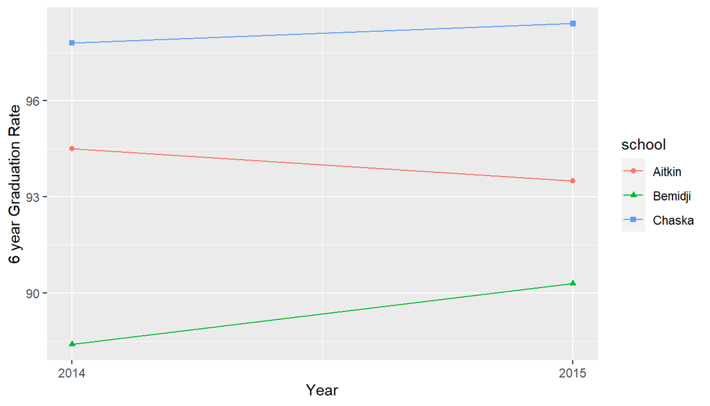

```r
> grad_narrower %>% filter(type=="gradRate6") %>%
+ ggplot(aes(x=as.numeric(year),y=gradRate)) + geom_line(aes(color=school))+
+   geom_point(aes(color=school,shape=school)) + labs(x="Year",y="6 year Graduation Rate") +
+   scale_x_continuous(breaks=c(2014,2015))
```

## Plotting grad rates (layer using `linetype`)

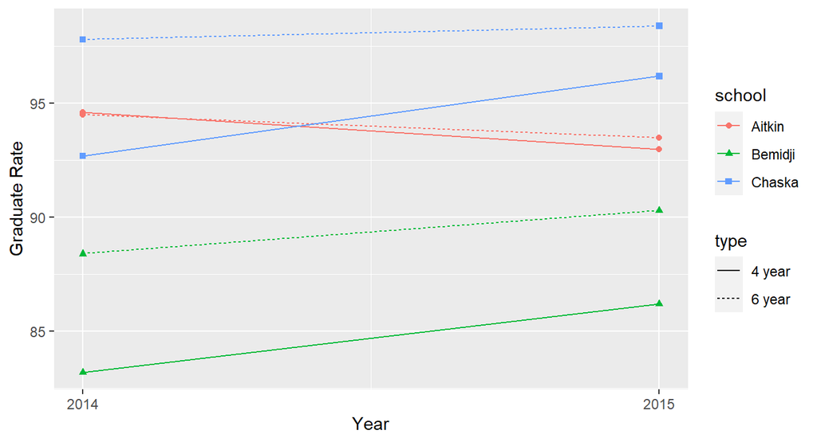

```r
> ggplot(grad_narrower, aes(x=as.numeric(year),y=gradRate)) +
+   geom_line(aes(color=school, linetype=type))+
+   geom_point(aes(color=school,shape=school)) + labs(x="Year",y="Graduate Rate") +
+   scale_x_continuous(breaks=c(2014,2015)) +
+   scale_linetype_discrete(labels=c("4 year","6 year"))
```

## Reshaping data: narrow to wide

- the `spread` command can convert narrow data into wide data
- `spread(narrow, key=, value=)`
  - `key` is the (existing) variable that will be used to name the new variables
  - `value` is the (existing) variable whose values will fill the new columns
  - if `key` has numeric values, add `sep="_"` to get the `key` row name attached to numeric values

```r
> grad_narrow
   school   region year gradRate
1  Aitkin northern 2015     93.0
2 Bemidji northern 2015     86.2
3  Chaska    metro 2015     96.2
4  Aitkin northern 2014     94.6
5 Bemidji northern 2014     83.2
6  Chaska    metro 2014     92.7
```

## Reshaping data: narrow to wide

```r
> spread(grad_narrow, key=year, value=gradRate)
   school   region 2014 2015
1  Aitkin northern 94.6 93.0
2 Bemidji northern 83.2 86.2
3  Chaska    metro 92.7 96.2
```

- columns with numeric names are more difficult to work with so add a `sep` argument:

```r
> spread(grad_narrow, key=year, value=gradRate, sep="_")
   school   region year_2014 year_2015
1  Aitkin northern      94.6      93.0
2 Bemidji northern      83.2      86.2
3  Chaska    metro      92.7      96.2
```

## Reshaping data: narrow to wide

- What if two variables (`type` and `year`) identify grad rates

```r
> grad_narrower
    school   region      type year gradRate
1   Aitkin northern gradRate4 2015     93.0
2  Bemidji northern gradRate4 2015     86.2
3   Chaska    metro gradRate4 2015     96.2
4   Aitkin northern gradRate4 2014     94.6
5  Bemidji northern gradRate4 2014     83.2
6   Chaska    metro gradRate4 2014     92.7
7   Aitkin northern gradRate6 2015     93.5
8  Bemidji northern gradRate6 2015     90.3
9   Chaska    metro gradRate6 2015     98.4
10  Aitkin northern gradRate6 2014     94.5
11 Bemidji northern gradRate6 2014     88.4
12  Chaska    metro gradRate6 2014     97.8
```

## Reshaping data: narrow to wide

- one way: `unite` into one variable
- default separator is `"_"`

```r
> grad_narrower2 <-  unite(grad_narrower, key, type, year)
> grad_narrower2
    school   region            key gradRate
1   Aitkin northern gradRate4_2015     93.0
2  Bemidji northern gradRate4_2015     86.2
3   Chaska    metro gradRate4_2015     96.2
4   Aitkin northern gradRate4_2014     94.6
5  Bemidji northern gradRate4_2014     83.2
6   Chaska    metro gradRate4_2014     92.7
7   Aitkin northern gradRate6_2015     93.5
8  Bemidji northern gradRate6_2015     90.3
9   Chaska    metro gradRate6_2015     98.4
10  Aitkin northern gradRate6_2014     94.5
11 Bemidji northern gradRate6_2014     88.4
12  Chaska    metro gradRate6_2014     97.8
```

## Reshaping data: narrow to wide

- Then spread with the united variable as key

```r
> spread(grad_narrower2, key=key, value=gradRate) %>% as_tibble()
# A tibble: 3 x 6
  school  region   gradRate4_2014 gradRate4_2015 gradRate6_2014 gradRate6_2015
  <chr>   <chr>             <dbl>          <dbl>          <dbl>          <dbl>
1 Aitkin  northern           94.6           93             94.5           93.5
2 Bemidji northern           83.2           86.2           88.4           90.3
3 Chaska  metro              92.7           96.2           97.8           98.4
```